# Exploratory Plots

# Introduction

The purpose of this document is to produce a number of plots that describe the relationships between variables in the cleaned, interpolated VMS data for all years from 2009-2018. Speficially, we explore differences in patterns of landings and effort over time, between VMS and non-VMS-equipped vessels, and between large and small vessels.

The cleaning of the data has been done elsewhere, but for the purposes of the following plots, the important points are:

- Raw VMS data were cleaned and checked for errors, and then linearly interpolated and regularized. We linearly interpolated between recorded VMS points to obtain a relative measure of speed and distance traveled during each trip, then regularized those data, choosing points along the paths such that we have a VMS record for each vessel at more regular intervals.
- A fishing “trip” (the unit of many of the analyses below) is defined as the collection of VMS records preceding a landed, recorded PacFIN fish ticket. This means that one “trip” could involve multiple returns to port by a vessel across multiple days, as long as there is no ticket submitted within that time frame.
- In data processing, VMS records were assigned to fish tickets using two criteria. First, for each ticket, we looked backwards to see when the previous ticket had been submitted, and assigned all VMS records after the previous ticket to the current ticket. Second, for those vessels with long periods between submitted tickets, we enforced a 10 day “lookback window”, such that the maximum number of calendar days of VMS records that could be associated with a single ticket is 10.
- We are focused here on fishing trips for Dungeness crab, but some vessels can participate in multiple fisheries. In data processing, if multiple tickets were submitted by a vessel on the same day, we denoted the primary target species for that trip as the species with the most landed pounds across all tickets. However, we also marked those trips so we can investigate any differences between single and multispecies fishing trips.

# Total Landings, Trips, and Number of Vessels over Time

In this section, we summarize the data on broad scales to look at total landings over time and representation of the fleet through VMS records.

```r
# File path where data are held
fp <- "C:/Users/Owen.Liu/Documents/NWFSC Research/Dungeness Fleet Dynamics/VMS DATA CONFIDENTIAL/Processed Data/VMS/"
fp_tix <- "C:/Users/Owen.Liu/Documents/NWFSC Research/Dungeness Fleet Dynamics/VMS DATA CONFIDENTIAL/Processed Data/Fish tickets/"

# Load Rdata files
# Interpolated, regularized VMS data, all years
vms_sf<-readRDS(file=paste0(fp,"VMS_int_reg_w_grid.rds"))

vms <- vms_sf
st_geometry(vms) <- NULL

# fish ticket data
load(file=paste0(fp_tix,"FishTix_all_2009_2018.RData"))
```

First we organize the fish ticket data, so we can calculate quantities of interest like total landings per month, number of unique vessels, and whether or not a fish ticket is associated with VMS data. We use the version of cleaned fish ticket data here that:

- contain all tickets, not just those that have associated VMS data
- contain vessel lengths

```r
# Summarize fish tickets by target species as defined above, and denote whether each trip is multispecies
fishtix <- fishtix_vlength_all %>%

  # start with all fishtickets for the year
  select(Rec_ID,pacfin_port_code,drvid,date,TARGET,DCRB..lbs.,LOBS..lbs.,SABL..lbs.,SPRW..lbs.,OtherGear..lbs., Other..lbs.,FINAL_LENGTH) %>%

  #rename port
  rename(Port_Of_Landing=pacfin_port_code) %>%

  # group by vessel
  group_by(drvid) %>%
  arrange(desc(date),pmin(DCRB..lbs.,LOBS..lbs.,SABL..lbs.,SPRW..lbs.,OtherGear..lbs., Other..lbs.)) %>%

  # For multiple-ticket days,
  # define "TARGET" from the ticket with most landed pounds for that day, but also retain the other targets in a string
  group_by(drvid, date) %>%
  mutate(all_spp=paste(TARGET,sep='',collapse=''),sumlbs=DCRB..lbs.+LOBS..lbs.+SABL..lbs.+SPRW..lbs.+OtherGear..lbs.+Other..lbs.) %>%
  top_n(1,wt=sumlbs) %>%
  select(-sumlbs) %>%
  ungroup() %>%

  # denote whether a trip is multispecies (binary)
  mutate(num_TARGET=nchar(all_spp)/4) %>%
  mutate(date=as_date(date,format="%m/%d/%Y",tz="America/Los_Angeles")) %>%
  mutate(month=month(date),year=year(date))
```

```r
# Add an indicator to fishtickets if they have associated VMS data
vms_fishtix_join <- vms %>%
  select(Rec_ID) %>%
  distinct() %>%
  mutate(has_vms=1) %>%
  right_join(fishtix,by="Rec_ID") %>%
  mutate(has_vms=replace_na(has_vms,0))
```

## Total Dungeness Vessels

- How many vessels recorded landings in each month in our data?
- What proportion of vessels have associated VMS data in each month?

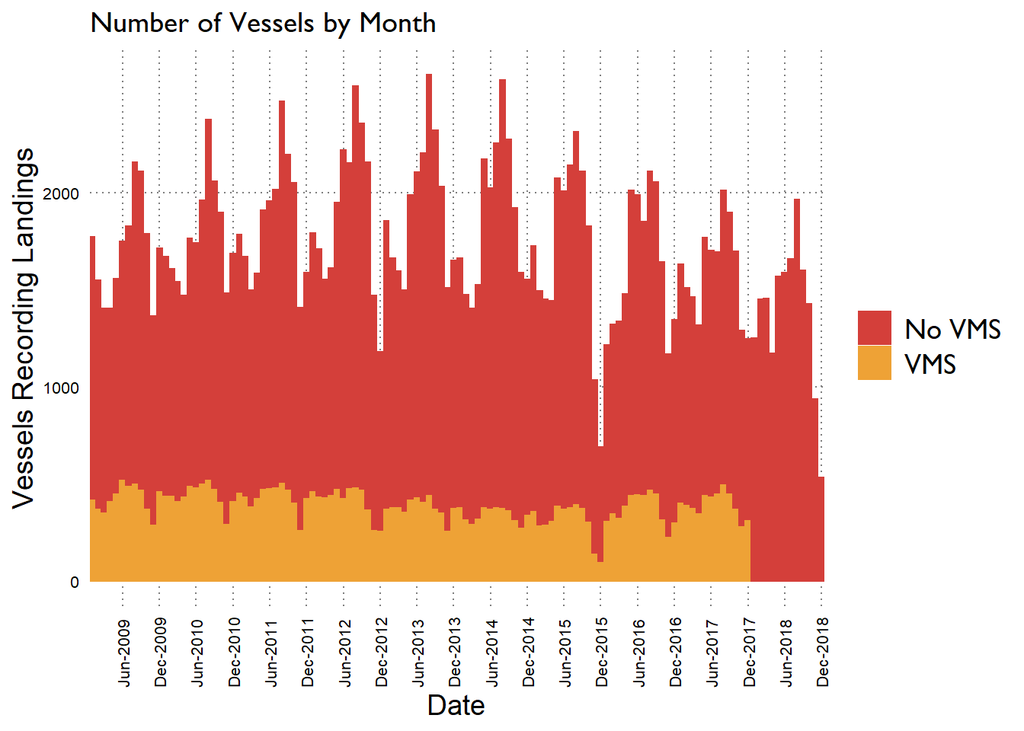

```r
nvessels_by_month <- vms_fishtix_join %>%
  group_by(year,month,has_vms) %>%
  summarise(nvessels=n_distinct(drvid)) %>%
  ungroup() %>%
  mutate(day=1) %>%
  unite(date,year,month,day,sep="-",remove = FALSE) %>%
  mutate(date=as_date(date,format="%Y-%m-%d",tz="America/Los_Angeles"))

nvessels_by_month %>%
  ggplot(aes(date,nvessels,fill=factor(has_vms),col=factor(has_vms)))+
  geom_bar(stat='identity')+
  scale_fill_locuszoom(name="",labels=c("No VMS","VMS"))+
  scale_color_locuszoom(name="",labels=c("No VMS","VMS"))+
  scale_x_date(date_breaks= "6 months",date_labels="%b-%Y",expand=c(0,0))+
  labs(x="Date",y="Vessels Recording Landings",title="Number of Vessels by Month")+
  theme(axis.text.x.bottom = element_text(angle=90,vjust=+0.5,hjust=0),
        panel.grid.minor = element_blank())
```

## Total Landings

- What are the total Dungeness landings represented in the fish ticket data over time?
- What proportion of those landings are represented in our VMS records?

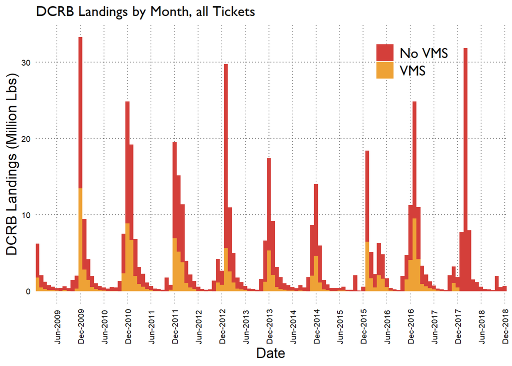

```r
landings_by_month <- vms_fishtix_join %>%
  group_by(year,month,has_vms) %>%
  summarise(DCRB_lbs=sum(DCRB..lbs.)) %>%
  mutate(DCRB_mt=DCRB_lbs/2204.62) %>%
  ungroup() %>%
  mutate(day=1) %>%
  unite(date,year,month,day,sep="-",remove = FALSE) %>%
  mutate(date=as_date(date,format="%Y-%m-%d",tz="America/Los_Angeles"))

landings_by_month %>%
  ggplot(aes(date,DCRB_lbs/1e6,fill=factor(has_vms),col=factor(has_vms)))+
  geom_bar(stat='identity')+
  scale_fill_locuszoom(labels=c("No VMS","VMS"),name="")+
  scale_color_locuszoom(labels=c("No VMS","VMS"),name="")+
  scale_x_date(date_breaks= "6 months",date_labels="%b-%Y",expand=c(0,0))+
  labs(x="Date",y="DCRB Landings (Million Lbs)",title="DCRB Landings by Month, all Tickets")+
  theme(legend.position = c(0.8,0.9))+
  theme(axis.text.x.bottom = element_text(angle=90,vjust=+0.5,hjust=0),
        panel.grid.minor = element_blank())
```

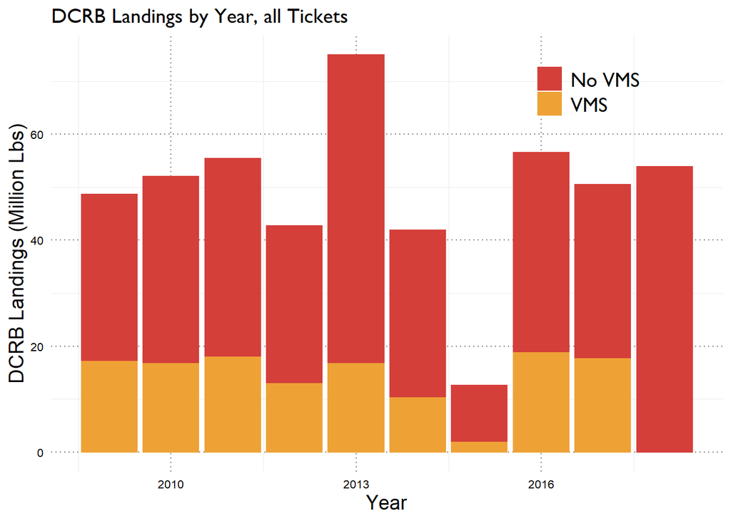

```r
landings_by_year <- vms_fishtix_join %>%
  group_by(year,has_vms) %>%
  summarise(DCRB_lbs=sum(DCRB..lbs.)) %>%
  mutate(DCRB_mt=DCRB_lbs/2204.62) %>%
  ungroup()

landings_by_year %>%
  ggplot(aes(year,DCRB_lbs/1e6,fill=factor(has_vms),col=factor(has_vms)))+
  geom_bar(stat='identity')+
  scale_fill_locuszoom(labels=c("No VMS","VMS"),name="")+
  scale_color_locuszoom(labels=c("No VMS","VMS"),name="")+
  labs(x="Year",y="DCRB Landings (Million Lbs)",title="DCRB Landings by Year, all Tickets")+
  theme(legend.position = c(0.8,0.9))
```

## Trips

How many total trips targeting Dungeness were there over time? Here, trips are defined (as above) as individual fish tickets, where the target was “DCRB”, or Dungeness crab. We distinguish whether or not these trips are associated with VMS data.

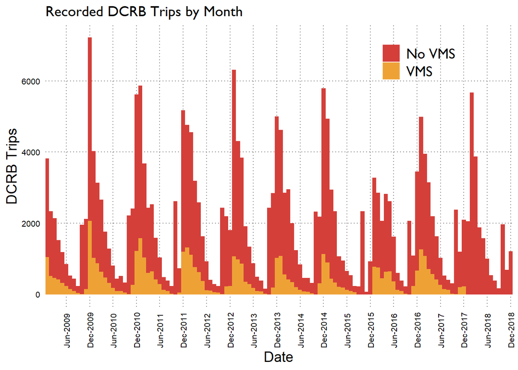

```r
trips_by_month <- vms_fishtix_join %>%
  group_by(year,month,has_vms) %>%
  filter(TARGET=="DCRB") %>%
  summarise(n_trips=n_distinct(Rec_ID)) %>%
  ungroup() %>%
  mutate(day=1) %>%
  unite(date,year,month,day,sep="-",remove = FALSE) %>%
  mutate(date=as_date(date,format="%Y-%m-%d",tz="America/Los_Angeles"))

trips_by_year <- vms_fishtix_join %>%
  group_by(year,has_vms) %>%
  filter(TARGET=="DCRB") %>%
  summarise(n_trips=n_distinct(Rec_ID)) %>%
  ungroup()

trips_by_month %>%
  ggplot(aes(date,n_trips,fill=factor(has_vms),col=factor(has_vms)))+
  geom_bar(stat='identity')+
  scale_fill_locuszoom(labels=c("No VMS","VMS"),name="")+
  scale_color_locuszoom(labels=c("No VMS","VMS"),name="")+
  scale_x_date(date_breaks= "6 months",date_labels="%b-%Y",expand=c(0,0))+
  labs(x="Date",y="DCRB Trips",title="Recorded DCRB Trips by Month")+
  theme(legend.position = c(0.8,0.9))+
  theme(axis.text.x.bottom = element_text(angle=90,vjust=+0.5,hjust=0),
        panel.grid.minor = element_blank())
```

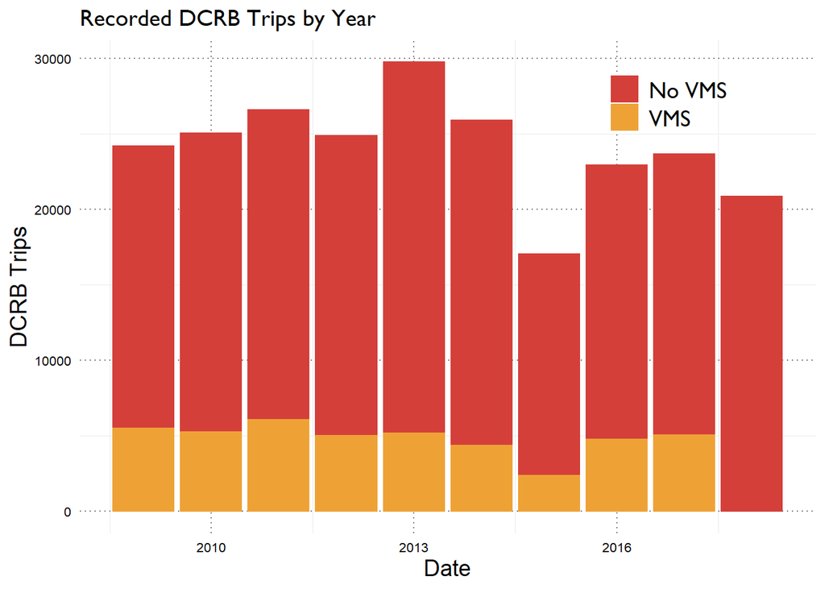

```r
trips_by_year %>%
  ggplot(aes(year,n_trips,fill=factor(has_vms),col=factor(has_vms)))+
  geom_bar(stat='identity')+
  scale_fill_locuszoom(labels=c("No VMS","VMS"),name="")+
  scale_color_locuszoom(labels=c("No VMS","VMS"),name="")+
  labs(x="Date",y="DCRB Trips",title="Recorded DCRB Trips by Year")+
  theme(legend.position = c(0.8,0.9))
```

## Trips vs. Landings

Do more trips imply greater landings? How tight (linear) is this relationship? Does it differ between VMS and non-VMS tickets?

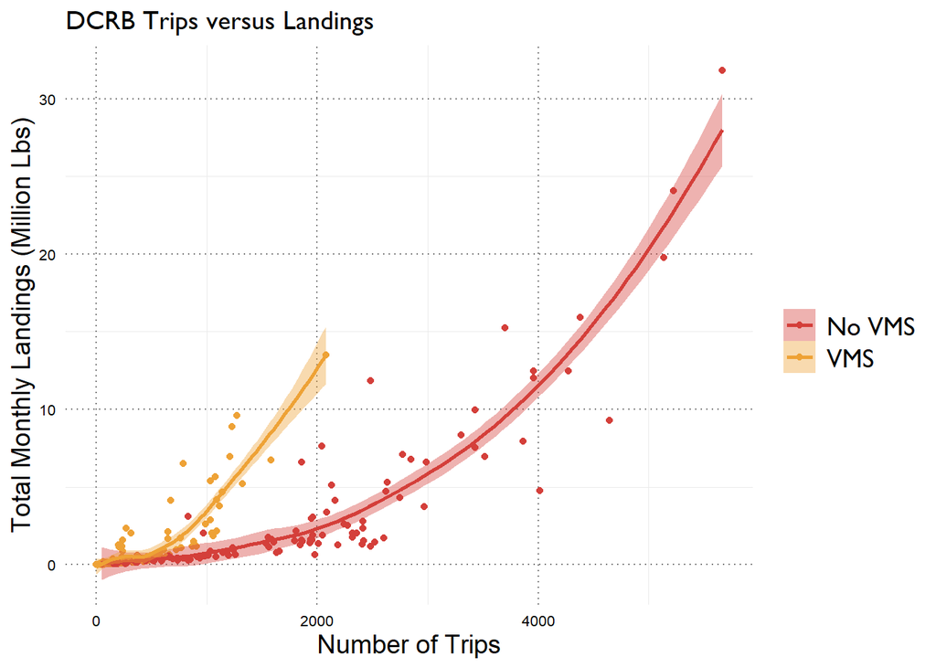

```r
trips_land_by_month <- landings_by_month %>%
  left_join(trips_by_month,by=c('year','month','day','date','has_vms'))

# Scatter plot
trips_land_by_month %>%
  ggplot(aes(n_trips,DCRB_lbs/1e6,col=factor(has_vms),fill=factor(has_vms)))+
  geom_point()+
  # geom_smooth(method='lm',se=F)+
  geom_smooth()+
  scale_color_locuszoom(labels=c("No VMS","VMS"),name="")+
  scale_fill_locuszoom(labels=c("No VMS","VMS"),name="")+
  labs(x="Number of Trips",y="Total Monthly Landings (Million Lbs)",title="DCRB Trips versus Landings")
```

A couple of things to notice here. First, the relationship between trips and landings is nonlinear. This makes some sense in a derby-type fishery, which we can see in the monthly landings plots above: Early in each season, effort is intense and catches are extremely high. Later in the season as crabs become more scarce, fishers may require a relatively greater number of trips to obtain the desired catch. That is the likely reason for the shape of these curves.

Second, there is some scatter around the basic relationship between trips and landings, suggesting there are some anomalously good (above the line) and poor (below the line) months.

Finally, there is a stark difference between VMS and non-VMS vessels in this relationship. Vessels with VMS (for whatever reason), obtain relatively greater monthly landings in fewer trips than non-VMS vessels. For example, in a month with ~1500 trips, VMS vessels could be expected to land approximately six million lbs of Dungeness, while non-VMS vessels would require twice that many trips to achieve the same landings. The exact reason for this discrepancy is unknown, but is likely a product of the relatively larger size and capcacity of VMS-equipped vessels. We can explore this further later on.

Next we turn to the calculation of catch-per-unit-effort, or CPUE, which describes the efficiency of fishing, and should shed further light on some of the relationships suggested in this plot.

# Comparison of Vessel Size

We can use this same data to compare how things like CPUE, trip length, and total landings vary as a function of vessel size. For now, we split vessels into “Large” (>40 ft long) and Small vessels.

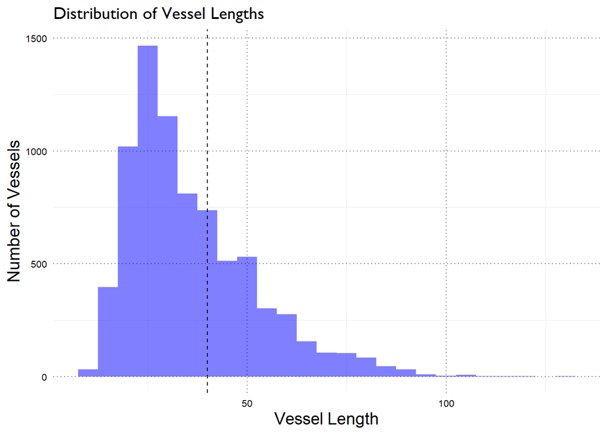

```r
fishtix %>%
  select(drvid,FINAL_LENGTH) %>%
  distinct() %>%
  ggplot(aes(FINAL_LENGTH))+
  geom_histogram(fill="blue",alpha=0.5,bins=25)+
  labs(x="Vessel Length",y="Number of Vessels",title="Distribution of Vessel Lengths")+
  geom_vline(xintercept = 40,linetype=2,color='black')
```

```r
# Define large vs. small vessels
vms_fishtix_join %<>% filter(!is.na(FINAL_LENGTH)) %>% mutate(is_large=FINAL_LENGTH>=40)
```

## Number of Vessels

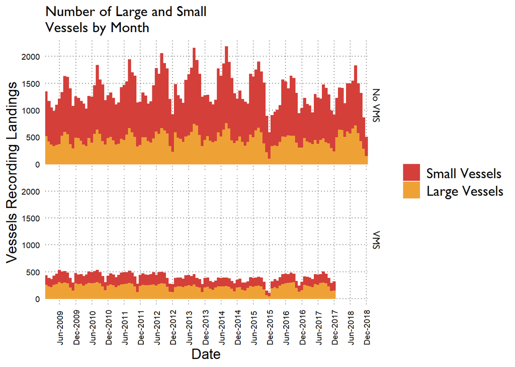

```r
nvessels_by_size_month <- vms_fishtix_join %>%
  mutate(has_vms=has_vms==1) %>%
  group_by(year,month,is_large,has_vms) %>%
  summarise(nvessels=n_distinct(drvid)) %>%
  ungroup() %>%
  mutate(day=1) %>%
  unite(date,year,month,day,sep="-",remove = FALSE) %>%
  mutate(date=as_date(date,format="%Y-%m-%d",tz="America/Los_Angeles"))

nvessels_by_size_month %>%
  ggplot(aes(date,nvessels,fill=is_large,col=is_large))+
  geom_bar(stat='identity')+
  facet_grid(rows = "has_vms",labeller = labeller(has_vms=c("FALSE"="No VMS","TRUE"="VMS")))+
  scale_fill_locuszoom(name="",labels=c("Small Vessels","Large Vessels"))+
  scale_color_locuszoom(name="",labels=c("Small Vessels","Large Vessels"))+
  scale_x_date(date_breaks= "6 months",date_labels="%b-%Y",expand=c(0,0))+
  labs(x="Date",y="Vessels Recording Landings",title="Number of Large and Small\nVessels by Month")+
  theme(axis.text.x.bottom = element_text(angle=90,vjust=+0.5,hjust=0),
        panel.grid.minor = element_blank())
```

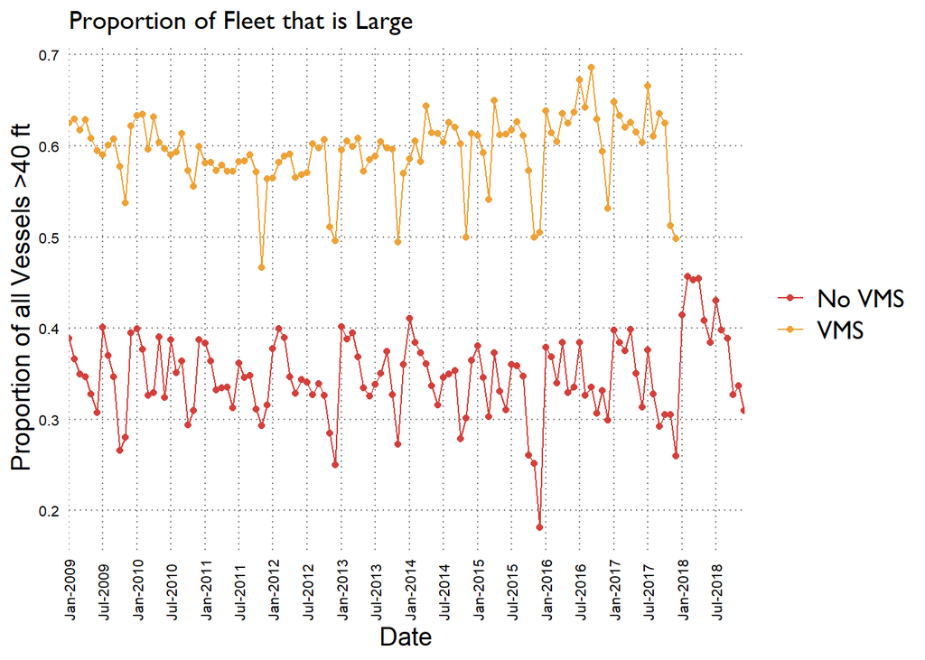

```r
# Proportion of Vessels that are large vs. small and VMS vs. non-VMS
nvessels_by_size_month %>%
  group_by(has_vms) %>%
  pivot_wider(names_from="is_large",values_from = "nvessels") %>%
  rename(Large="TRUE",Small="FALSE") %>%
  mutate(propLarge=Large/(Small+Large)) %>%
  ungroup() %>%
  ggplot(aes(date,propLarge,col=has_vms))+
  geom_point()+geom_line()+
  scale_x_date(date_breaks= "6 months",date_labels="%b-%Y",expand=c(0,0))+
  scale_color_locuszoom(name="",labels=c("No VMS","VMS"))+
  labs(x="Date",y="Proportion of all Vessels >40 ft",title="Proportion of Fleet that is Large")+
  theme(axis.text.x.bottom = element_text(angle=90,vjust=+0.5,hjust=0),
        panel.grid.minor = element_blank())
```

An interesting thing to notice here is how the proportion of the fleet comprised of large boats is smallest at the beginning of each crab season (November and December). This may indicate that a lot of small boats participate in the fishery for just a couple of months before dropping out, while the large boats are more consistent participants in the fishery throughout the season.

## Landings

What were the landings generated by large vs small vessels?

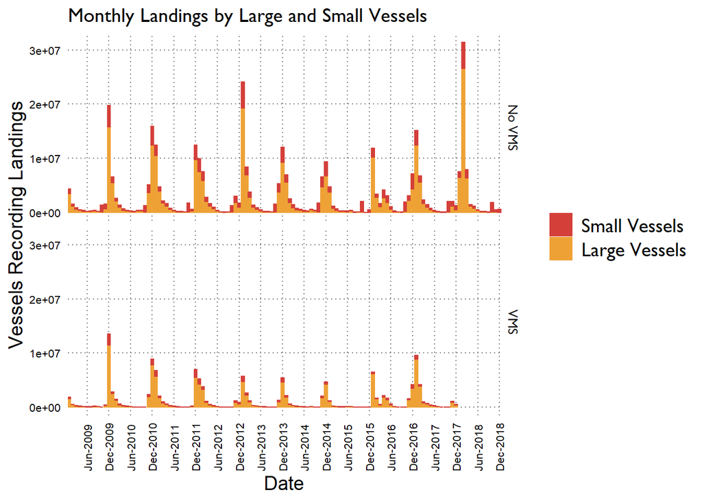

```r
landings_by_size_month <- vms_fishtix_join %>%
  mutate(has_vms=has_vms==1) %>%
  group_by(year,month,is_large,has_vms) %>%
  summarise(landings=sum(DCRB..lbs.,na.rm = T)) %>%
  ungroup() %>%
  mutate(day=1) %>%
  unite(date,year,month,day,sep="-",remove = FALSE) %>%
  mutate(date=as_date(date,format="%Y-%m-%d",tz="America/Los_Angeles"))

landings_by_size_month %>%
  ggplot(aes(date,landings,fill=is_large,col=is_large))+
  geom_bar(stat='identity')+
  facet_grid(rows = "has_vms",labeller = labeller(has_vms=c("FALSE"="No VMS","TRUE"="VMS")))+
  scale_fill_locuszoom(name="",labels=c("Small Vessels","Large Vessels"))+
  scale_color_locuszoom(name="",labels=c("Small Vessels","Large Vessels"))+
  scale_x_date(date_breaks= "6 months",date_labels="%b-%Y",expand=c(0,0))+
  labs(x="Date",y="Vessels Recording Landings",title="Monthly Landings by Large and Small Vessels")+
  theme(axis.text.x.bottom = element_text(angle=90,vjust=+0.5,hjust=0),
        panel.grid.minor = element_blank())
```

From these data, it is clear that vessels greater than 40 feet long account for a large majority of landings in both the VMS and non-VMS equipped fleets.

# Catch per unit Effort

Here we explore the relationship between catch (landed pounds of crab) and effort. We will try to investigate whether there is consistency between different measures of effort (trips, VMS hours, distance traveled) in their relationships to landings.

## Trips vs. Landings

We got a sense of the (non-linear) relationship between trips and landings. We can look at this again through individual vessel cpue, and over time.

We can calculate number of trips and monthly landings On the individual vessel level (no longer summarizing over all vessels).

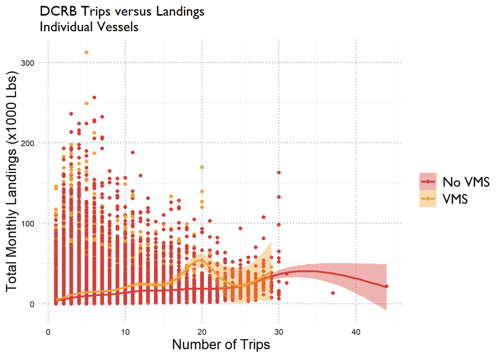

```r
trips_by_vessel_month <- vms_fishtix_join %>%
  filter(TARGET=="DCRB") %>%
  group_by(year,month,drvid,has_vms) %>%
  summarise(n_trips=n_distinct(Rec_ID),tot_lbs=sum(DCRB..lbs.)) %>%
  ungroup() %>%
  mutate(day=1) %>%
  unite(date,year,month,day,sep="-",remove = FALSE) %>%
  mutate(date=as_date(date,format="%Y-%m-%d",tz="America/Los_Angeles"))

trips_by_vessel_month %>%
  ggplot(aes(n_trips,tot_lbs/1e3,col=factor(has_vms),fill=factor(has_vms)))+
  geom_point()+
  # geom_smooth(method='lm',se=F)+
  geom_smooth()+
  scale_color_locuszoom(labels=c("No VMS","VMS"),name="")+
  scale_fill_locuszoom(labels=c("No VMS","VMS"),name="")+
  labs(x="Number of Trips",y="Total Monthly Landings (x1000 Lbs)",title="DCRB Trips versus Landings\nIndividual Vessels")
```

Here, it seems that there is immense individual variation in landings between vessels, with no clear indication that more trips in a month necessarily lead to more landings. However, there is some pattern to these data—The largest individual-vessel monthly landings occur with a small number of trips (~2-7 trips in a month). There are, in my mind, a couple of explanations for this pattern:

- As in the previous section, we could be seeing an artifact of the fishery being very productive early in each season, with a relatively small number of trips leading to large amounts of landings.
- In addition to the seasonality, this observation could be partly due to the way we have defined trips (as all of the activity preceding a submitted landings receipt/fish ticket). Vessels can presumably transit in and out of port multiple times, storing catch before officially filling out a landings receipt. If this is the case, early in the season when the fishing is very good, fishers may be rushing to capture crab and only submitting tickets when they have filled available storage space. Later in the season, when many fishers are presumably more diversified, they may submit multiple smaller tickets at shorter time intervals. This would have the effect of increasing the number of trips rewquired to obtain a certain level of landings, which would help explain the phenomenon above.

We can investigate these two possibilities further by looking at CPUE over time and by substituting different measures of effort to replace trips and see if the relationships look similar.

## Landings per Trip over Time

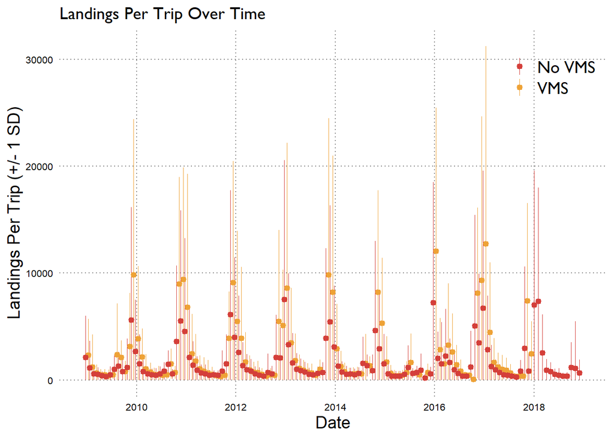

```r
cpue_by_ticket <- trips_by_vessel_month %>%
  mutate(cpue_month=tot_lbs/n_trips) %>%
  group_by(year,month,has_vms) %>%
  summarise(mean_cpue=mean(cpue_month,na.rm=T),sd_cpue=sd(cpue_month,na.rm=T),
            upper=mean_cpue+sd_cpue,lower=pmax(0,mean_cpue-sd_cpue)) %>% mutate(day=1) %>%
  unite(date,year,month,day,sep="-",remove = FALSE) %>%
  mutate(date=as_date(date,format="%Y-%m-%d",tz="America/Los_Angeles"))

dodge <- position_dodge(width=40)
cpue_by_ticket %>%
  ggplot(aes(date,mean_cpue,ymax=upper,ymin=lower,col=factor(has_vms),group=factor(has_vms)))+
  geom_pointrange(position = dodge,size=0.3)+
  scale_color_locuszoom(name="",labels=c("No VMS","VMS"))+
  labs(x="Date",y="Landings Per Trip (+/- 1 SD)",title="Landings Per Trip Over Time")+
  theme(panel.grid.minor = element_blank(),
        legend.position = c(0.9,0.9))
```

This is a messy plot, but the point is clear: At the individual vessel level, landings per trip peak early in the season and decline rapidly thereafter. One other thing I notice here is that again, VMS-equipped vessels (yellow) seem to have significantly higher landings per trip relative to their non-VMS counterparts (red).

## Landings per Day

Another way we can calculate effort is to look at not just the number of trips, but the length of each of those trips. Our expectation would be that longer trips (greater number of days) result in greater landings, but that this relationship may attenuate as the crab season progresses.

```r
# calculate the number of days associated with each fish ticket
fishtix_trip_time <- vms_fishtix_join %>%
  group_by(drvid) %>%
  arrange(desc(date)) %>%
  mutate(end = ymd_hms(paste(date, "23:59:59"),tz= "America/Los_Angeles")) %>%
  # find the ticket BEFORE each ticket and note its time.
  mutate(prev_ticket_dttm=lead(end,1)) %>%
  mutate(ticket_days=time_length(end-prev_ticket_dttm,"days")) %>%
  # if multiple tickets on one day,set ticket_days to 1
  mutate(ticket_days=recode(ticket_days,`0`=1)) %>%
  # now, select just the DCRB trips
  filter(TARGET=="DCRB") %>%
  arrange(drvid,desc(date)) %>%
  ungroup()

# What is the distribution of trip lengths for all vessels?
quantile(fishtix_trip_time$ticket_days,probs = seq(0,1,by=0.1),na.rm=T)
```

```
##           0%          10%          20%          30%          40%
##    0.9583333    1.0000000    1.0000000    2.0000000    3.0000000
##          50%          60%          70%          80%          90%
##    4.0000000    5.0000000    6.0000000    9.0000000   14.0000000
##         100%
## 3022.0416667
```

```r
quantile(fishtix_trip_time$ticket_days,0.95,na.rm=T)
```

```
## 95%
##  26
```

Five percent of trips have greater than 26 days since the previous ticket. These observations are very likely not representative of actual trip length, so we exclude these (although we could revisit this filtering later). Now we calculate the new CPUE measure: landed pounds per trip-day.

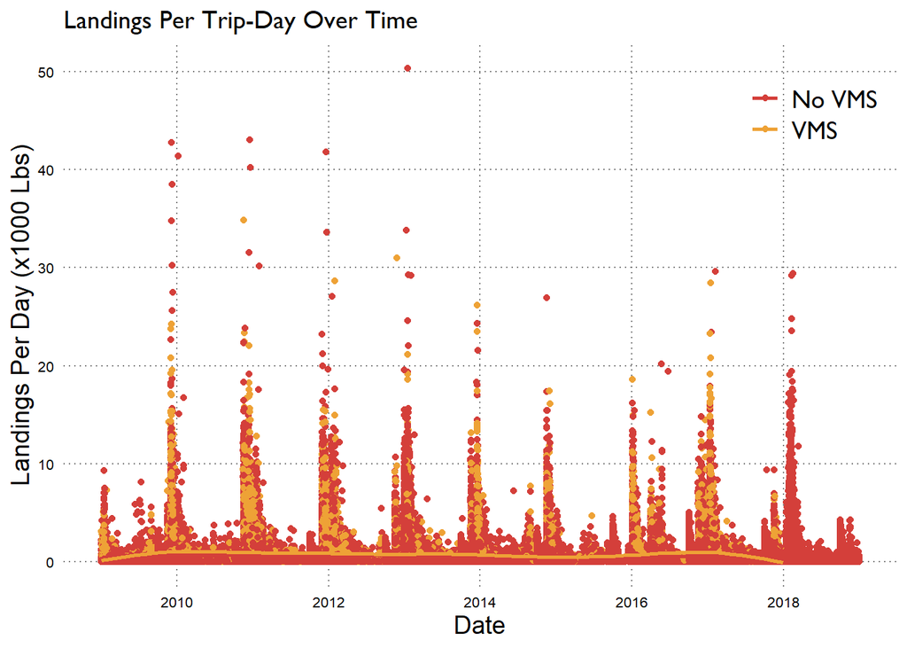

```r
cpue_trip_time <- fishtix_trip_time %>%
  filter(ticket_days<=26) %>%
  mutate(cpue_per_day=DCRB..lbs./ticket_days)

# Plot
cpue_trip_time %>%
  ggplot(aes(date,cpue_per_day/1e3,col=factor(has_vms)))+
  geom_point()+
  geom_smooth(se=F)+
  scale_color_locuszoom(name="",labels=c("No VMS","VMS"))+
  labs(x="Date",y="Landings Per Day (x1000 Lbs)",title="Landings Per Trip-Day Over Time")+
  theme(panel.grid.minor = element_blank(),
        legend.position = c(0.9,0.9))
```

At least at a first glance, the temporal pattern in this catch per day data looks similar to the monthly average catch per trip. However, it doesn’t seem to have as stark a difference between VMS and non-VMS vessels. What about if we look more directly at trip days versus landings?

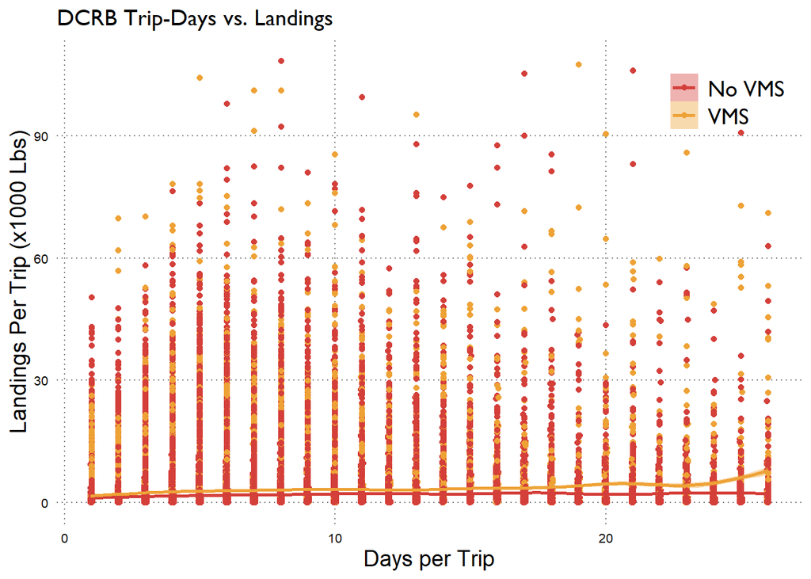

```r
cpue_trip_time %>%
  ggplot(aes(ticket_days,DCRB..lbs./1e3,col=factor(has_vms),fill=factor(has_vms)))+
  geom_point()+
  geom_smooth()+
  scale_color_locuszoom(name="",labels=c("No VMS","VMS"))+
  scale_fill_locuszoom(name="",labels=c("No VMS","VMS"))+
  labs(x="Days per Trip",y="Landings Per Trip (x1000 Lbs)",title="DCRB Trip-Days vs. Landings")+
  theme(panel.grid.minor = element_blank(),
        legend.position = c(0.9,0.9))
```

We again see evidence of medium-length trips being the most productive, perhaps near the beginning of the season. What if we separate out these data by month?

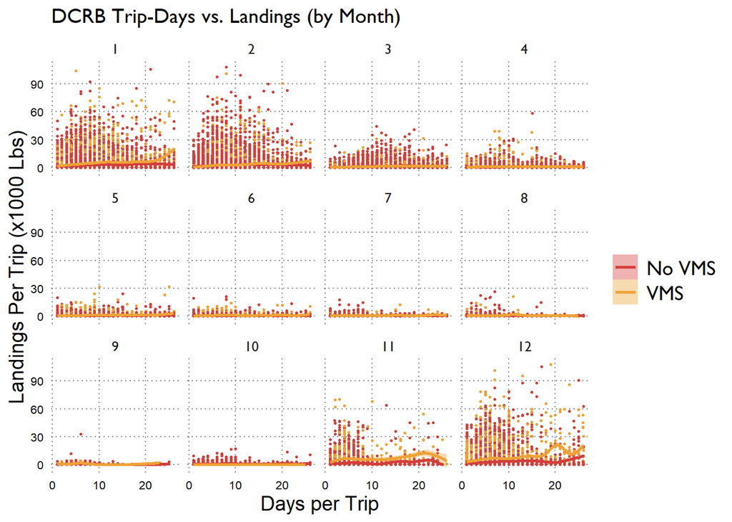

```r
cpue_trip_time %>%
  ggplot(aes(ticket_days,DCRB..lbs./1e3,col=factor(has_vms),fill=factor(has_vms)))+
  geom_jitter(size=0.5)+
  geom_smooth()+
  scale_color_locuszoom(name="",labels=c("No VMS","VMS"))+
  scale_fill_locuszoom(name="",labels=c("No VMS","VMS"))+
  labs(x="Days per Trip",y="Landings Per Trip (x1000 Lbs)",title="DCRB Trip-Days vs. Landings (by Month)")+
  facet_wrap(~month)+
  theme(panel.grid.minor = element_blank())
```

Even in early-season months (November through February), we still get a similar patterns.

We can also compare the two measures of CPUE we have constructed so far.

```r
# Because catch per trip is a monthly aggregation measure, we have to do the same for catch per day
cpue_trip_time_by_month <- cpue_trip_time %>%
  group_by(year,month,has_vms) %>%
  summarise(mean_cpue_tripdays=mean(cpue_per_day,na.rm=T),sd_cpue_tripdays=sd(cpue_per_day,na.rm=T),
            upper_cpue_tripdays=mean_cpue_tripdays+sd_cpue_tripdays,
            lower_cpue_tripdays=pmax(0,mean_cpue_tripdays-sd_cpue_tripdays)) %>%
  mutate(day=1) %>%
  unite(date,year,month,day,sep="-",remove = FALSE) %>%
  mutate(date=as_date(date,format="%Y-%m-%d",tz="America/Los_Angeles")) %>%
  ungroup()
cpue_trips_days_combine <- cpue_by_ticket %>% left_join(cpue_trip_time_by_month)
```

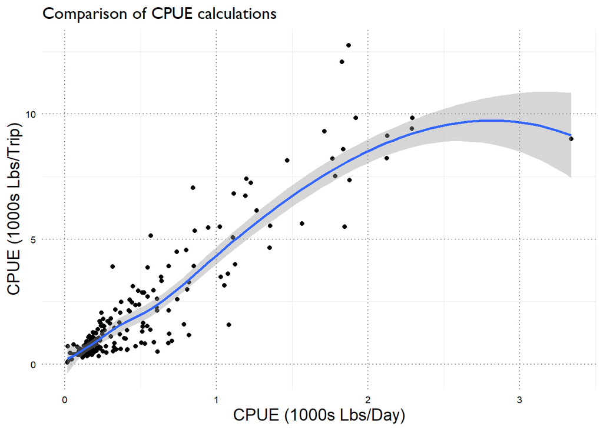

```r
cpue_trips_days_combine %>%
  ggplot(aes(mean_cpue_tripdays/1e3,mean_cpue/1e3))+
  geom_point()+
  geom_smooth()+
  labs(x="CPUE (1000s Lbs/Day)",y="CPUE (1000s Lbs/Trip)",title="Comparison of CPUE calculations")
```

The two CPUE measures are correlated by not extremely precisely related. Hence, care should be taken when a CPUE measure like this is used, and appropriate justification should be provided..

Ideally, a better measure of fishing efficiency would be using data on actual catch per individual crab pot per soak time. This may become available through logbook data, but is currently unavailable.

## Distance traveled

As a final measure of CPUE with our current data, we can actually calculate distance traveled during each trip and compare that to the total landings from each trip. This measurement of CPUE only works for VMS-equipped vessels. Note: these will be straight-line distances between linearly-interpolated VMS points. Therefore, they are not precisely the distances traveled by these vessels, but should be a good proxy for total distance.

First we calculate distances from the coordinates of interpolated VMS points.

```r
# get coordinates in Lat/Long
vms_coords <- vms_sf %>%
  st_transform(4326) %>%
  st_coordinates()
vms_coords %<>% as_tibble() %>% set_names(c('lon','lat'))

# Join trip identifiers from fish ticket data and then calculate distances along the path of each trip
vms_dists <- vms %>%
  select(Rec_ID,DOCNUM,westcoastdate) %>%
  bind_cols(vms_coords) %>%
  group_by(Rec_ID) %>%
  mutate(last_x=lag(lon,1),last_y=lag(lat,1)) %>%
  ungroup() %>%
  mutate(distance=distHaversine(cbind(lon,lat),cbind(last_x,last_y)))

# summarize each trip, adding up total distance traveled
trips_dists <- vms_dists %>%
  group_by(Rec_ID) %>%
  summarise(totdist=sum(distance,na.rm=T)) %>%
  ungroup()
```

Then, we calculate CPUE again, but this time it is defined as total catch per km traveled. Remember, in this case, our analysis is restricted to those vessels for which we have VMS data.

```r
cpue_trip_dist <- vms_fishtix_join %>%
  filter(has_vms==1) %>%
  left_join(trips_dists) %>%
  mutate(cpue_dist=DCRB..lbs./totdist)
glimpse(cpue_trip_dist)
```

```
## Observations: 146,150
## Variables: 20
## $ Rec_ID          <dbl> 496829378, 505206327, 505208016, 505210686, 50...
## $ has_vms         <dbl> 1, 1, 1, 1, 1, 1, 1, 1, 1, 1, 1, 1, 1, 1, 1, 1...
## $ Port_Of_Landing <chr> "ORF", "MOS", "SB", "ERK", "BRG", "BDG", "ERK"...
## $ drvid           <chr> "574591", "CF8760TR", "CF5914KP", "288626", "6...
## $ date            <date> 2017-12-31, 2017-12-31, 2017-12-31, 2017-12-3...
## $ TARGET          <chr> "SABL", "DCRB", "SHP1", "SABL", "SABL", "SABL"...
## $ DCRB..lbs.      <dbl> 0.00, 113.00, 0.00, 0.00, 0.00, 0.00, 0.00, 0....
## $ LOBS..lbs.      <dbl> 0.0, 0.0, 0.0, 0.0, 0.0, 0.0, 0.0, 0.0, 0.0, 0...
## $ SABL..lbs.      <dbl> 575, 0, 0, 628, 518, 720, 1015, 1285, 0, 0, 0,...
## $ SPRW..lbs.      <dbl> 0, 0, 0, 0, 0, 0, 0, 0, 0, 0, 0, 0, 0, 0, 0, 0...
## $ OtherGear..lbs. <dbl> 0, 0, 0, 0, 0, 0, 0, 0, 0, 0, 0, 0, 0, 0, 0, 0...
## $ Other..lbs.     <dbl> 315.00, 0.00, 106.00, 0.00, 0.00, 20.00, 0.00,...
## $ FINAL_LENGTH    <dbl> 37, 27, 27, 33, 30, 38, 30, 48, 40, 27, 34, 45...
## $ all_spp         <chr> "SABL", "DCRB", "SHP1", "SABL", "SABL", "SABL"...
## $ num_TARGET      <dbl> 1, 1, 1, 1, 1, 1, 1, 2, 1, 2, 2, 1, 1, 2, 1, 1...
## $ month           <dbl> 12, 12, 12, 12, 12, 12, 12, 12, 12, 12, 12, 12...
## $ year            <dbl> 2017, 2017, 2017, 2017, 2017, 2017, 2017, 2017...
## $ is_large        <lgl> FALSE, FALSE, FALSE, FALSE, FALSE, FALSE, FALS...
## $ totdist         <dbl> 28997.21, 25888.37, 21292.67, 105586.66, 41803...
## $ cpue_dist       <dbl> 0.000000000, 0.004364894, 0.000000000, 0.00000...
```

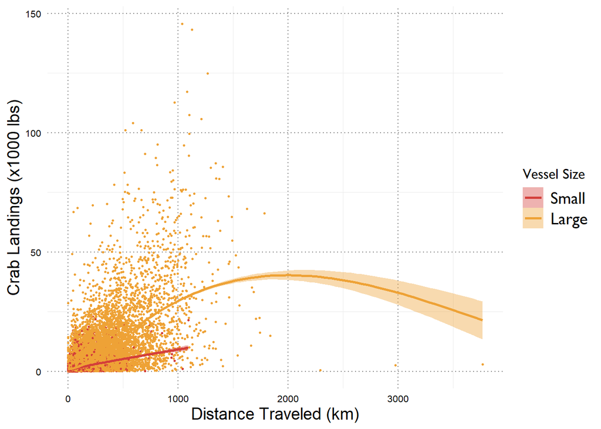

```r
# Distance traveled versus total catch per trip (trips targeted Dungeness)
cpue_trip_dist %>%
  filter(TARGET=="DCRB") %>%
  ggplot(aes(totdist/1000,DCRB..lbs./1000,col=is_large,fill=is_large))+
  geom_point(size=0.5)+
  geom_smooth()+
  scale_color_locuszoom(name="Vessel Size",labels=c("Small","Large"))+
  scale_fill_locuszoom(name="Vessel Size",labels=c("Small","Large"))+
  labs(x="Distance Traveled (km)",y="Crab Landings (x1000 lbs)")
```

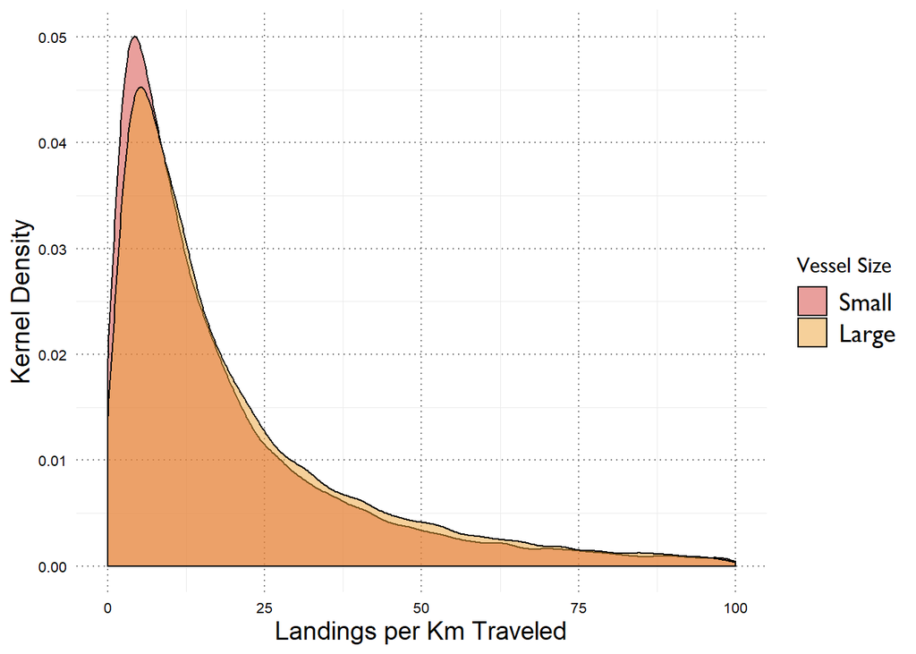

```r
# Distribution of CPUE per km traveled
cpue_trip_dist %>%
  filter(TARGET=="DCRB") %>%
  ggplot(aes(cpue_dist*1000,..density..,fill=is_large))+
  geom_density(alpha=0.5)+
  scale_fill_locuszoom(name="Vessel Size",labels=c("Small","Large"))+
  xlim(0,100)+
  labs(x="Landings per Km Traveled",y="Kernel Density")
```

This relationship is very noisy. There are many trips with a catch-per-km that is less than 10. At the same time, there is a long right tail, where some trips have extremely high landings relative to their distance traveled. However, from the first plot, it looks as though large vessels may scale more steeply with distance traveled than small vessels, which might be expected if large vessels are more efficient.

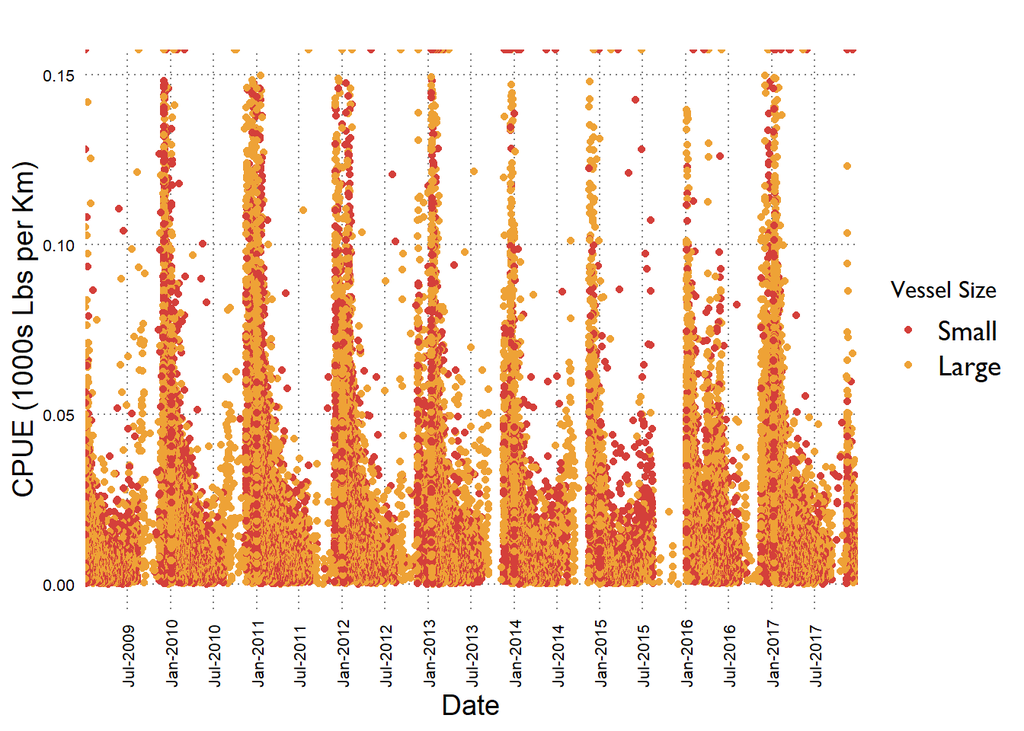

```r
# cpue_by_dist_month <- cpue_trip_dist %>%
#   filter(TARGET=="DCRB") %>%
#   ungroup() %>%
#   group_by(year,month,is_large) %>%
#   summarise(mean_cpue_tripdist=mean(cpue_dist,na.rm=T),sd_cpue_tripdist=sd(cpue_dist,na.rm=T),
#             upper_cpue_tripdist=mean_cpue_tripdist+sd_cpue_tripdist,
#             lower_cpue_tripdist=pmax(0,mean_cpue_tripdist-sd_cpue_tripdist)) %>%
#   mutate(day=1) %>%
#   unite(date,year,month,day,sep="-",remove = FALSE) %>%
#   mutate(date=as_date(date,format="%Y-%m-%d",tz="America/Los_Angeles")) %>%
#   ungroup()

cpue_trip_dist %>%
  filter(TARGET=="DCRB") %>%
  ggplot(aes(date,cpue_dist,col=is_large))+
  geom_point()+
  scale_color_locuszoom(name="Vessel Size",labels=c("Small","Large"))+
  scale_x_date(date_breaks= "6 months",date_labels="%b-%Y",expand=c(0,0))+
  ylim(0,0.15)+
  labs(x="Date",y="CPUE (1000s Lbs per Km)",title="")+
  theme(panel.grid.minor = element_blank(),
        axis.text.x = element_text(angle=90,vjust=+0.5,hjust=0))
```

```r
# What about just by month of the year
# cpue_by_dist_month %>%
#   mutate(monthchr=month(month,label=T)) %>%
#   ggplot(aes(monthchr,mean_cpue_tripdist,col=is_large))+
#   geom_point()+
#   scale_color_locuszoom(name="Vessel Size",labels=c("Small","Large"))+
#   labs(x="Month",y="Mean CPUE (1000 Lbs per Km)",title="")+
#   theme(panel.grid.minor = element_blank(),
#         axis.text.x = element_text(angle=90,vjust=+0.5,hjust=0))
```

Let’s compare landings per day to landings per km traveled. Again, we are interested in how correlated these two representations of CPUE are.

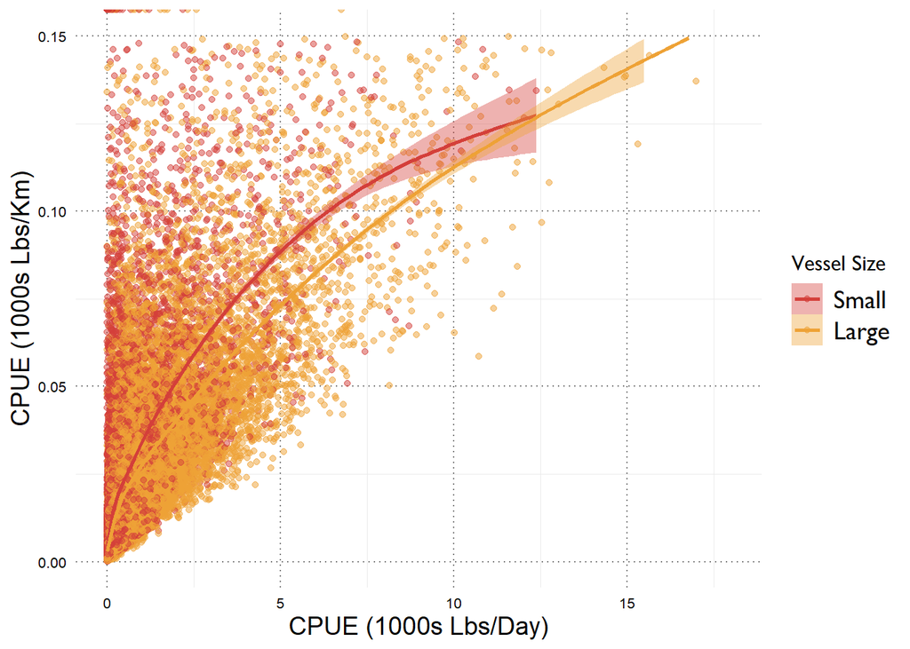

```r
cpue_trip_dist %>%
  left_join(cpue_trip_time) %>%
  filter(has_vms==1) %>%
  ggplot(aes(cpue_per_day/1e3,cpue_dist,col=is_large,fill=is_large))+
  geom_point(alpha=0.5)+
  geom_smooth()+
  ylim(0,0.15)+xlim(0,18)+
  scale_color_locuszoom(name="Vessel Size",labels=c("Small","Large"))+
  scale_fill_locuszoom(name="Vessel Size",labels=c("Small","Large"))+
  labs(x="CPUE (1000s Lbs/Day)",y="CPUE (1000s Lbs/Km)")
```